# 2° Parcial - Distribuciones de Probabilidad y simulaciones Montecarlo -

### Eleccion de tabla de datos: Distribución Normal

- Para la eleccion de la tabla de datos, realizamos un experimento de tiempo de reaccion (reflejos). El procedimiento es el siguiente:

1er paso: se necesitan dos alumnos, uno enfrente del otro. Al alumno “A” le vamos a dar una regla de unos 30 cms.

2do paso: el alumno “A” va a tomar la regla por un extremo, quedando esta última en posición vertical.

3er paso: el alumno “B” va a posicionar su mano en una determinada posición de la regla, preferentemente en el extremo opuesto de la regla. Su mano tiene que quedar en posición de pinza como para detener la caída.

4to paso: el alumno “A” va a dejar caer la regla en un momento aleatorio y el “B” va detener la caída de la misma con su mano.

5to paso: anotar cuánto cayó la regla.

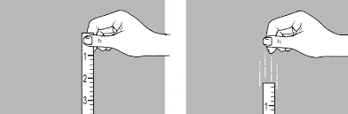

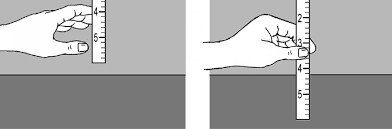

Los sujetos de prueba fueron los alumnos y el profesor (NACHO, LAUTA, MARIO, RAFA) con un total de 30 datos cada uno.

Una vez obtenidas las pruebas, con la ayuda de ChatGPT vamos a crear una tabla tidy con el nombre “datos_tidy”:

```r
library(tidyr)
library(ggplot2)

datos <- data.frame(
  NACHO = c(23, 23.5, 26, 24, 20, 21.5, 22, 19, 20.5, 18.5, 19, 16, 20, 20.5, 29, 24, 24, 21.5, 19, 27, 22, 19, 21.5, 14.5, 17.5, 19, 23, 20.5, 20.5, 16.5),
  LAUTA = c(30, 19, 17, 15.5, 20, 30, 16.5, 19.5, 16, 15, 15.5, 18, 22, 19, 17, 18.5, 18.5, 17, 18, 17, 18, 18, 17.5, 17, 20, 20, 18, 20.5, 14.5, 20),
  MARIO = c(15, 5, 5, 8, 3, 11.5, 16, 15, 10, 11, 13, 15, 13, 5, 2, 17, 19, 10, 7, 25, 11, 3, 5, 17, 12, 19, 17, 4, 19, 12),
  RAFA = c(25.5, 23, 24.5, 21.5, 24.5, 25, 17, 12, 20.5, 20, 24, 17.5, 23.5, 18, 25.5, 25.5, 30, 27.5, 20, 22, 20.5, 24, 23, 24.5, 20.5, 20.5, 23, 20, 18, 24)
)

datos_tidy <- gather(datos, key = NOMBRE, value = VALOR,)
# print(datos_tidy)
```

### Indicadores matemáticos:

Separamos las informaciones de las tablas por nombres information tener un mejor manejo de la informacion:

```r
tablaNACHO <- subset(datos_tidy, NOMBRE == 'NACHO')
# tablaNACHO
tablaLAUTA <- subset(datos_tidy, NOMBRE == 'LAUTA')
# tablaLAUTA
tablaMARIO <- subset(datos_tidy, NOMBRE == 'MARIO')
# tablaMARIO
tablaRAFA <- subset(datos_tidy, NOMBRE == 'RAFA')
# tablaRAFA
```

- Analisis de valores principales:

```r
summary(datos)
```

```
     NACHO           LAUTA           MARIO            RAFA
 Min.   :14.50   Min.   :14.50   Min.   : 2.00   Min.   :12.00
 1st Qu.:19.00   1st Qu.:17.00   1st Qu.: 5.50   1st Qu.:20.12
 Median :20.50   Median :18.00   Median :11.75   Median :23.00
 Mean   :21.07   Mean   :18.75   Mean   :11.48   Mean   :22.17
 3rd Qu.:23.00   3rd Qu.:19.88   3rd Qu.:15.75   3rd Qu.:24.50
 Max.   :29.00   Max.   :30.00   Max.   :25.00   Max.   :30.00
```

## Graficos

### Histograma

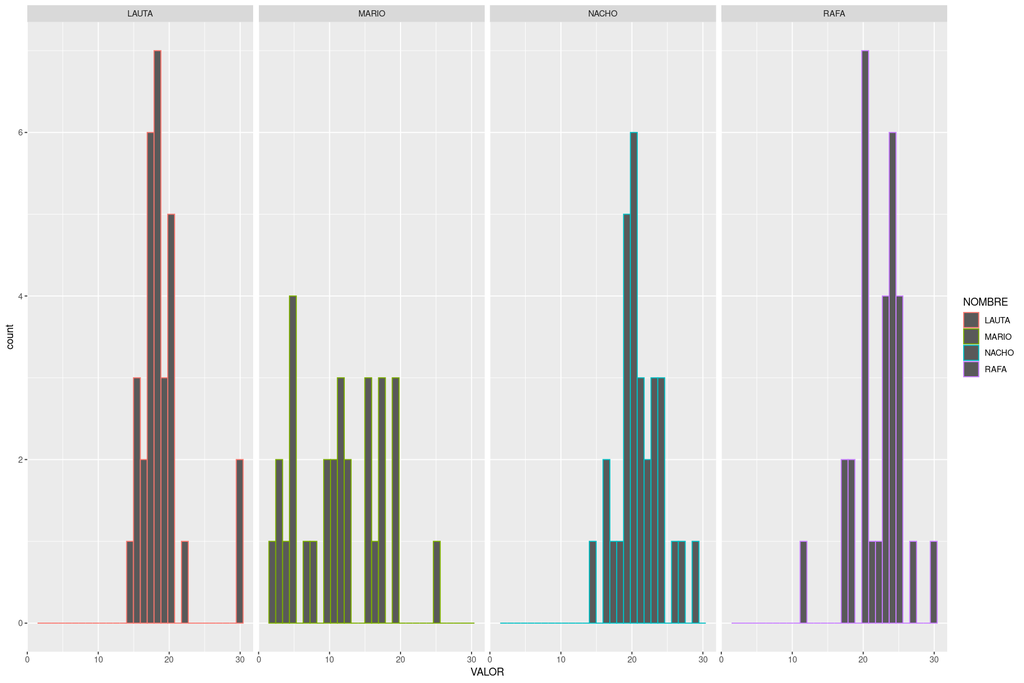

```r
library(ggplot2)
ggplot(datos_tidy, aes(VALOR, color = NOMBRE)) +
  geom_histogram() +
  facet_grid(rows =, cols = vars(NOMBRE))
```